# Data Science Lecture HA2 - Lösung

### Q2

> 2. Unterscheidet sich die Verteilung der Körpergrößen von Erwachsenen zwischen den Ethnien in der NHANES-Studie? Erzeugen Sie Histogramme (geom_histogram) oder Verteilungskurven (geom_density), um dieser Frage nachzugehen, und bilden Sie sich eine erste Meinung.

Histograme

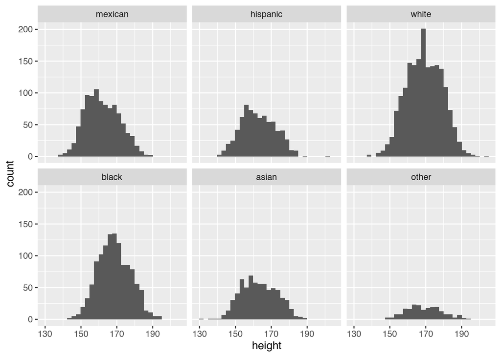

```r
nhanes %>%
  filter( age >= 18 ) %>%
  ggplot +
    geom_histogram( aes( height ), size = .2 ) +
    facet_wrap( ~ ethnicity )
```

Um zu vergleichen, kann es helfen, die Histogramme so zu skalieren, dass alle dieselbe Fläche (nämlich 1) haben. Dazu spezifizieren wir `stat(density)`:

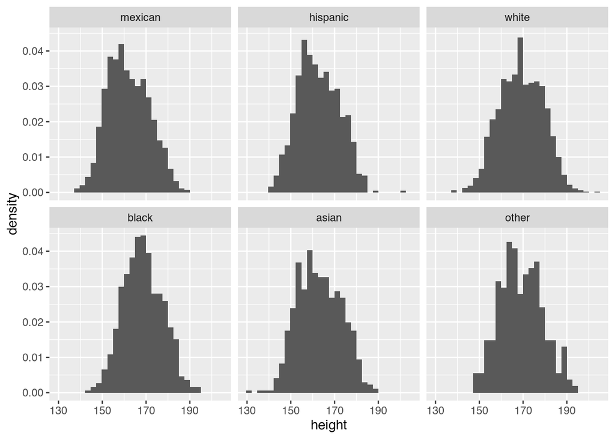

```r
nhanes %>%
  filter( age >= 18 ) %>%
  ggplot +
    geom_histogram( aes( height, stat(density) ), size = .2 ) +
    facet_wrap( ~ ethnicity )
```

Wir können auch alle Histogramme übereinander legen:

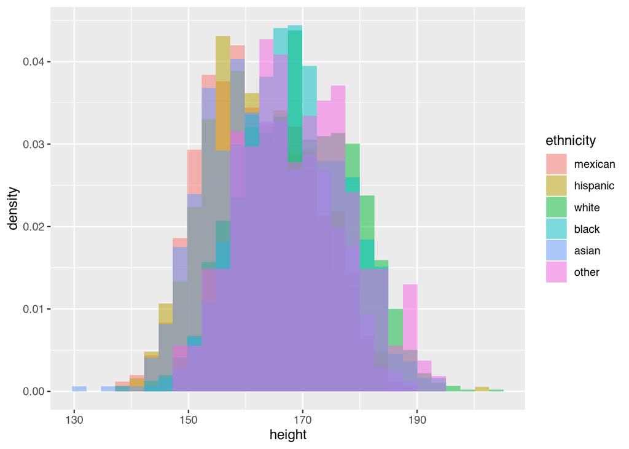

```r
nhanes %>%
  filter( age >= 18 ) %>%
  ggplot +
    geom_histogram( aes( height, fill=ethnicity, stat(density) ),
       position="identity" , size = .2, alpha=.5 )
```

Wenn wir Verteilungskuven statt Histogrammen benutzen, erkennt man mehr

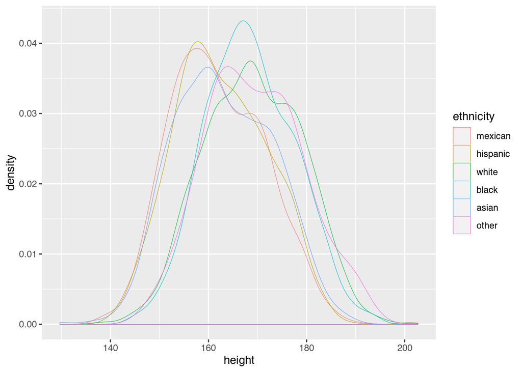

```r
nhanes %>%
  filter( age >= 18 ) %>%
  ggplot +
    geom_density( aes( height, col = ethnicity ), size = .2 )
```

*mexican*, *hispanic* und *asian* scheinen kleiner zu sein als *white*, *black* und *other*.

### Q3

> 3. Die von Erwachsenen erreichte Körpergröße hängt, neben der Genetik, auch stark von der Ernährung in den ersten drei Lebensjahren ab. Studienteilnehmer, die nicht in den USA geboren wurden (siehe Tabellen-Spalte “bornInUS”), sind vielleicht als Kind in die USA immigriert, weil ihre Eltern wirtschaftlich schwierigen Verhältnissen entflohen. Ist daher eine Abhängigkeit der Körpergröße vom “BornInUS”-Status erkennbar? Überprüfen Sie dies für jede Ethnie separat.

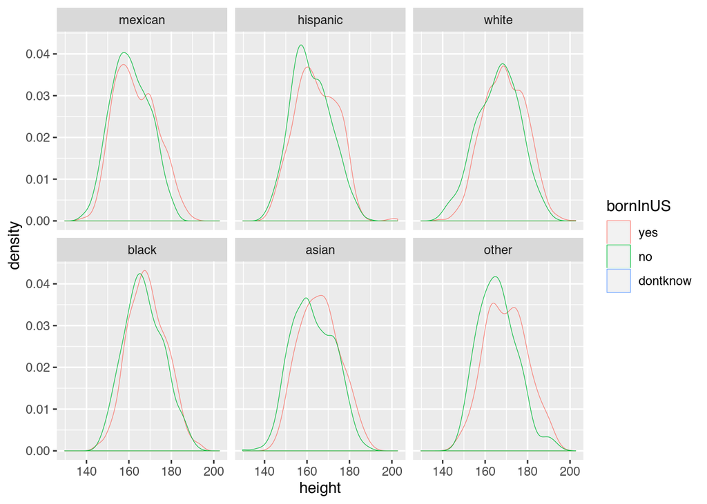

```r
nhanes %>%
  filter( age >= 18 ) %>%
  ggplot +
    geom_density( aes( height, col = bornInUS ), size = .2 ) +
    facet_wrap( ~ ethnicity )
```

Wo sind die Unterschiede statistisch signikant? Das überlegen wir uns das nächste Mal.

### Q4

> 4. Ein Ergebnis einfach anzugeben, ist eine Sache, es auch gut zu begründen, eine andere. Verfassen Sie für eines der Ergebnisse der vorstehenden Fragen einen kurzen “Bericht” (vielleicht eine gute halbe Seite), der die Fragestellung darstellt, die Daten erläutert, die zur Beantwortung verwendeten Daten genau angibt, die Rechnung erläutert, und das Ergebnis nicht nur als Zahl wiedergibt, sondern auch durch einen geeigneten Plot veranschaulicht.